# Geog533 Final Exam

## Question 8 (20 pt.)

Use **us_state.shp** and **NDVI.nc** to complete the following tasks.

### Question 8(a)

Extract and plot the maps of monthly NDVI of the year 2002.

```r
library(raster)
library(ncdf4)
ndvi <- brick("data/NDVI.nc")
ndvi
```

```
class       : RasterBrick
dimensions  : 360, 720, 259200, 36  (nrow, ncol, ncell, nlayers)
resolution  : 0.5, 0.5  (x, y)
extent      : -180, 180, -90, 90  (xmin, xmax, ymin, ymax)
coord. ref. : +proj=longlat +datum=WGS84 +ellps=WGS84 +towgs84=0,0,0
data source : C:\STATS\Final\Final test\data\NDVI.nc
names       : X2000.01.01, X2000.02.01, X2000.03.01, X2000.04.01, X2000.05.01, X2000.06.01, X2000.07.01, X2000.08.01, X2000.09.01, X2000.10.01, X2000.11.01, X2000.12.01, X2001.01.01, X2001.02.01, X2001.03.01, ...
Date        : 2000-01-01, 2002-12-01 (min, max)
varname     : NDVI
```

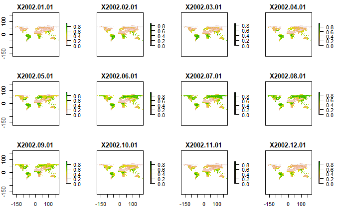

```r
plot(ndvi,25:36)
```

```r
ndviagg <- brick(nd)
```

```
Error in brick(nd) : object 'nd' not found
```

### Question 8(b)

Aggregate the 12 bands of the year 2002 to generate a mean NDVI raster.

```r
mean(x)
```

```
argument is not numeric or logical: returning NA
```

```
[1] NA
```

### Question 8(c)

Plot the above mean NDVI raster with us_state.shp overlaid on top.

```r
read.csv("data/us_state.shp")
```

[output not shown]

[output not shown]

### Question 8(d)

Use us_state.shp as a mask to clip the mean NDVI raster.

### Question 8(e)

Plot and save the above clipped raster.

## Question 9 (20 pt.)

Use the provided **earthquake.txt** to create an interactive map using leaflet. The popup box for each point must show the earthquake information, including Station ID, latitude, longitude, depth, and magnitude. See the map below for example.

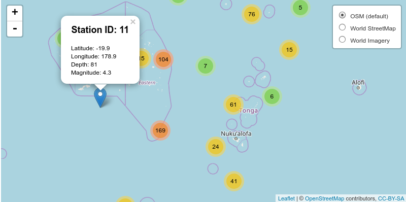

```r
if(!require(leaflet)) install.packages("leaflet")
library(leaflet)
df <- read.csv("data/earthquakes.txt")
df$lat.long.depth.mag.stations = as.character(lapply(strsplit(as.character(df$location), split=","), "[", 1))
```

```
Error in `$<-.data.frame`(`*tmp*`, lat.long.depth.mag.stations, value = character(0)) :
  replacement has 0 rows, data has 1000
```

## Question 10 (20 pt.)

Central Bank prints paper money each year. For each year they need an estimate of how much money to be printed. The decision is based on various economic indicators like GDP, Interest rate, and WPI-based inflation, etc. Use the provided **money.csv** to construct multiple linear regression models.

### Question 10(a)

Construct a multiple linear regression model that uses GDP, Interest_RATE, and WPI as independent variables to predict Money_printed.

```r
summary(m)
```

```
Call:
lm(formula = df$Money_printed ~ df$GDP + df$Interest_RATE + df$WPI)

Residuals:
   Min     1Q Median     3Q    Max
-46875  -7027   1387  15068  46249

Coefficients:
                   Estimate Std. Error t value Pr(>|t|)
(Intercept)      -1.759e+04  5.052e+04  -0.348  0.73008
df$GDP            2.975e-01  8.787e-02   3.385  0.00195 **
df$Interest_RATE -1.626e+04  2.919e+03  -5.570 4.19e-06 ***
df$WPI            2.943e+01  9.038e+02   0.033  0.97423
---
Signif. codes:  0 ‘***’ 0.001 ‘**’ 0.01 ‘*’ 0.05 ‘.’ 0.1 ‘ ’ 1

Residual standard error: 22770 on 31 degrees of freedom
Multiple R-squared:  0.9848,    Adjusted R-squared:  0.9834
F-statistic: 670.4 on 3 and 31 DF,  p-value: < 2.2e-16
```

### Question 10(b)

Comment on the above regression model. Which independent variable(s) is insignificant?

### Question 10(c)

If you have an opportunity to improve the regression model, what would you do? Print out the improved regression model, if any.

```r
#Remove WPI because it is insignificant
m <- lm(df$Money_printed~df$GDP+df$Interest_RATE)
summary(m)
```

```
Call:
lm(formula = df$Money_printed ~ df$GDP + df$Interest_RATE)

Residuals:
   Min     1Q Median     3Q    Max
-47055  -7168   1432  14998  46008

Coefficients:
                   Estimate Std. Error t value Pr(>|t|)
(Intercept)      -1.906e+04  2.192e+04  -0.870    0.391
df$GDP            3.003e-01  6.913e-03  43.443  < 2e-16 ***
df$Interest_RATE -1.619e+04  1.977e+03  -8.191 2.35e-09 ***
---
Signif. codes:  0 ‘***’ 0.001 ‘**’ 0.01 ‘*’ 0.05 ‘.’ 0.1 ‘ ’ 1

Residual standard error: 22420 on 32 degrees of freedom
Multiple R-squared:  0.9848,    Adjusted R-squared:  0.9839
F-statistic:  1038 on 2 and 32 DF,  p-value: < 2.2e-16
```

### Question 10(d)

Based on the improved regression model, predict how much money should be printed if GDP, Interest_RATE, and WPI are 2800000, 7.1, and 210, respectively.